# Final Project

## By: Rohan Ondkar, Naveen Harish, Melvin Gonsalves

# Part 1: Why are we collecting this data?

Early education is important for a number of reasons. First and foremost, young children are at a critical stage in their development, and early education can play a crucial role in shaping their future. By providing children with a strong foundation in key areas such as language, literacy, and mathematics, early education can help to prepare them for success in school and in life.

Another reason why early education is important is that it can help to narrow the achievement gap that often exists between children from different backgrounds. Children who receive high-quality early education are more likely to do well in school and go on to graduate from high school and attend college. This can help to break the cycle of poverty that affects many families and communities.

One major factor contributing to unequal education in the US is the unequal distribution of funding for schools. In many states, schools are funded primarily through property taxes, which means that schools in more affluent areas tend to have more funding than those in poorer areas. This leads to a situation where schools in wealthier neighborhoods are able to offer more advanced classes, extracurricular activities, and resources such as computers and modern facilities, while schools in poorer areas may struggle to provide even basic education.

This is exactly what we will be trying to to prove throughout this tutorial. Our focus is to confirm whether education inequality is reflected by national math and reading examination differences. One approach you could take is to collect data on national math and reading exam scores, and compare them across different demographic groups. This could include looking at factors such as race, income, and geographic location, to see if there are any significant differences in exam scores

Once we have collected and analyzed this data, we can then use it to confirm whether education inequality is reflected by national math and reading examination differences, and identify the factors that may be contributing to these differences. This information can then be used to inform efforts to address education inequality and improve early education for all students.

We will be using math and read as the subjects to look into because they are the most consistent and are taught at all school at an elementary level. It is common to use national math and reading exam scores as a way to measure educational achievement and inequality, because these subjects are considered fundamental to a student's overall educational experience. Math and reading skills are essential for success in many other academic subjects, as well as in daily life, and they are often included in standardized tests as a way to assess a student's overall academic performance. Additionally, math and reading exam scores can provide a more objective measure of educational achievement and inequality than other indicators, such as graduation rates or self-reported survey data. This can make them a useful tool for identifying and addressing disparities in educational opportunities and outcomes.

# Part 2: Data Management/Representation

First we have to import the necessary libraries that we need to load the dataset. We are using pandas, numpy, and matplotlib.pyplot.  
Pandas is used for the DataFrame object since that is an easy way to store tabular data.  
Numpy is used for its math functionality.  
Mathplotlib.pyplot is used to plot graphs demonstrating relationships between variables in our data.

```python
import pandas as pd
import numpy as np
import matplotlib.pyplot as plt
import geopandas
```

Getting the csv file and displaying it. Found at https://www.kaggle.com/datasets/noriuk/us-education-datasets-unification-project

```python
school = pd.read_csv("education_states.csv")

# display first few rows
school
```

|  | PRIMARY_KEY | STATE | YEAR | ENROLL | TOTAL_REVENUE | FEDERAL_REVENUE | STATE_REVENUE | LOCAL_REVENUE | TOTAL_EXPENDITURE | INSTRUCTION_EXPENDITURE | ... | G08_HI_A_READING | G08_HI_A_MATHEMATICS | G08_AS_A_READING | G08_AS_A_MATHEMATICS | G08_AM_A_READING | G08_AM_A_MATHEMATICS | G08_HP_A_READING | G08_HP_A_MATHEMATICS | G08_TR_A_READING | G08_TR_A_MATHEMATICS |
| --- | --- | --- | --- | --- | --- | --- | --- | --- | --- | --- | --- | --- | --- | --- | --- | --- | --- | --- | --- | --- | --- |
| 0 | 1992_ALABAMA | ALABAMA | 1992 | NaN | 2678885.0 | 304177.0 | 1659028.0 | 715680.0 | 2653798.0 | 1481703.0 | ... | NaN | NaN | NaN | NaN | NaN | NaN | NaN | NaN | NaN | NaN |
| 1 | 1992_ALASKA | ALASKA | 1992 | NaN | 1049591.0 | 106780.0 | 720711.0 | 222100.0 | 972488.0 | 498362.0 | ... | NaN | NaN | NaN | NaN | NaN | NaN | NaN | NaN | NaN | NaN |
| 2 | 1992_ARIZONA | ARIZONA | 1992 | NaN | 3258079.0 | 297888.0 | 1369815.0 | 1590376.0 | 3401580.0 | 1435908.0 | ... | NaN | NaN | NaN | NaN | NaN | NaN | NaN | NaN | NaN | NaN |
| 3 | 1992_ARKANSAS | ARKANSAS | 1992 | NaN | 1711959.0 | 178571.0 | 958785.0 | 574603.0 | 1743022.0 | 964323.0 | ... | NaN | NaN | NaN | NaN | NaN | NaN | NaN | NaN | NaN | NaN |
| 4 | 1992_CALIFORNIA | CALIFORNIA | 1992 | NaN | 26260025.0 | 2072470.0 | 16546514.0 | 7641041.0 | 27138832.0 | 14358922.0 | ... | NaN | NaN | NaN | NaN | NaN | NaN | NaN | NaN | NaN | NaN |
| ... | ... | ... | ... | ... | ... | ... | ... | ... | ... | ... | ... | ... | ... | ... | ... | ... | ... | ... | ... | ... | ... |
| 1710 | 2019_VIRGINIA | VIRGINIA | 2019 | NaN | NaN | NaN | NaN | NaN | NaN | NaN | ... | 247.0 | 278.0 | 286.0 | 315.0 | NaN | NaN | NaN | NaN | 269.0 | 293.0 |
| 1711 | 2019_WASHINGTON | WASHINGTON | 2019 | NaN | NaN | NaN | NaN | NaN | NaN | NaN | ... | 248.0 | 267.0 | 285.0 | 315.0 | 237.0 | 259.0 | NaN | NaN | 263.0 | 292.0 |
| 1712 | 2019_WEST_VIRGINIA | WEST_VIRGINIA | 2019 | NaN | NaN | NaN | NaN | NaN | NaN | NaN | ... | NaN | NaN | NaN | NaN | NaN | NaN | NaN | NaN | 249.0 | NaN |
| 1713 | 2019_WISCONSIN | WISCONSIN | 2019 | NaN | NaN | NaN | NaN | NaN | NaN | NaN | ... | 251.0 | 273.0 | 277.0 | 294.0 | 253.0 | 267.0 | NaN | NaN | 268.0 | 276.0 |
| 1714 | 2019_WYOMING | WYOMING | 2019 | NaN | NaN | NaN | NaN | NaN | NaN | NaN | ... | 254.0 | 274.0 | NaN | NaN | 243.0 | 258.0 | NaN | NaN | NaN | 274.0 |

1715 rows × 266 columns

PRIMARY_KEY is not needed for this table. We have STATE and YEAR, so we do not need PRIMARY_KEY because it provides no new information

```python
school = school.drop(columns=['PRIMARY_KEY'])

school
```

|  | STATE | YEAR | ENROLL | TOTAL_REVENUE | FEDERAL_REVENUE | STATE_REVENUE | LOCAL_REVENUE | TOTAL_EXPENDITURE | INSTRUCTION_EXPENDITURE | SUPPORT_SERVICES_EXPENDITURE | ... | G08_HI_A_READING | G08_HI_A_MATHEMATICS | G08_AS_A_READING | G08_AS_A_MATHEMATICS | G08_AM_A_READING | G08_AM_A_MATHEMATICS | G08_HP_A_READING | G08_HP_A_MATHEMATICS | G08_TR_A_READING | G08_TR_A_MATHEMATICS |
| --- | --- | --- | --- | --- | --- | --- | --- | --- | --- | --- | --- | --- | --- | --- | --- | --- | --- | --- | --- | --- | --- |
| 0 | ALABAMA | 1992 | NaN | 2678885.0 | 304177.0 | 1659028.0 | 715680.0 | 2653798.0 | 1481703.0 | 735036.0 | ... | NaN | NaN | NaN | NaN | NaN | NaN | NaN | NaN | NaN | NaN |
| 1 | ALASKA | 1992 | NaN | 1049591.0 | 106780.0 | 720711.0 | 222100.0 | 972488.0 | 498362.0 | 350902.0 | ... | NaN | NaN | NaN | NaN | NaN | NaN | NaN | NaN | NaN | NaN |
| 2 | ARIZONA | 1992 | NaN | 3258079.0 | 297888.0 | 1369815.0 | 1590376.0 | 3401580.0 | 1435908.0 | 1007732.0 | ... | NaN | NaN | NaN | NaN | NaN | NaN | NaN | NaN | NaN | NaN |
| 3 | ARKANSAS | 1992 | NaN | 1711959.0 | 178571.0 | 958785.0 | 574603.0 | 1743022.0 | 964323.0 | 483488.0 | ... | NaN | NaN | NaN | NaN | NaN | NaN | NaN | NaN | NaN | NaN |
| 4 | CALIFORNIA | 1992 | NaN | 26260025.0 | 2072470.0 | 16546514.0 | 7641041.0 | 27138832.0 | 14358922.0 | 8520926.0 | ... | NaN | NaN | NaN | NaN | NaN | NaN | NaN | NaN | NaN | NaN |
| ... | ... | ... | ... | ... | ... | ... | ... | ... | ... | ... | ... | ... | ... | ... | ... | ... | ... | ... | ... | ... | ... |
| 1710 | VIRGINIA | 2019 | NaN | NaN | NaN | NaN | NaN | NaN | NaN | NaN | ... | 247.0 | 278.0 | 286.0 | 315.0 | NaN | NaN | NaN | NaN | 269.0 | 293.0 |
| 1711 | WASHINGTON | 2019 | NaN | NaN | NaN | NaN | NaN | NaN | NaN | NaN | ... | 248.0 | 267.0 | 285.0 | 315.0 | 237.0 | 259.0 | NaN | NaN | 263.0 | 292.0 |
| 1712 | WEST_VIRGINIA | 2019 | NaN | NaN | NaN | NaN | NaN | NaN | NaN | NaN | ... | NaN | NaN | NaN | NaN | NaN | NaN | NaN | NaN | 249.0 | NaN |
| 1713 | WISCONSIN | 2019 | NaN | NaN | NaN | NaN | NaN | NaN | NaN | NaN | ... | 251.0 | 273.0 | 277.0 | 294.0 | 253.0 | 267.0 | NaN | NaN | 268.0 | 276.0 |
| 1714 | WYOMING | 2019 | NaN | NaN | NaN | NaN | NaN | NaN | NaN | NaN | ... | 254.0 | 274.0 | NaN | NaN | 243.0 | 258.0 | NaN | NaN | NaN | 274.0 |

1715 rows × 265 columns

We are going to use data after 2009 because anything before this does not take DEMOGRAPHICS into account... and thats kinda what we want to do

```python
#setup for 2009. Getting the previous and current length setup
prev = len(school.index)
school = school[school['YEAR'] >= 2009]
curr = len(school.index)
```

# Part 3: Exploratory Data Analysis

For our analysis we will examine any possible trends between states and average scores in math/reading for 4th graders over the years.

To do this, we can create a "GROWTH" variable that will calculate the difference between the average 4th grade math and reading scores from 2009 and the average 4th grade scores from 2015. If there is no inequality in education among states, we would expect that all states would have experienced the same change in average scores from 2009 to 2015. To visualize these comparisons, we will create heat plots to compare the data for each state.

Since the geopandas library we will be using to create the map requires geometrical coordinates, we need to get the grid coordinates of the United States map with state outlines. We obtained our map shapefile and other necessary mapping files from the US Census (the shapefile used).

```python
#reading shapefile to get geometric coordinates (MULTIPOLYGON objects)
states = geopandas.read_file("cb_2018_us_state_500k.shp")
states.head()
```

|  | STATEFP | STATENS | AFFGEOID | GEOID | STUSPS | NAME | LSAD | ALAND | AWATER | geometry |
| --- | --- | --- | --- | --- | --- | --- | --- | --- | --- | --- |
| 0 | 28 | 01779790 | 0400000US28 | 28 | MS | Mississippi | 00 | 121533519481 | 3926919758 | MULTIPOLYGON (((-88.50297 30.21523, -88.49176 ... |
| 1 | 37 | 01027616 | 0400000US37 | 37 | NC | North Carolina | 00 | 125923656064 | 13466071395 | MULTIPOLYGON (((-75.72681 35.93584, -75.71827 ... |
| 2 | 40 | 01102857 | 0400000US40 | 40 | OK | Oklahoma | 00 | 177662925723 | 3374587997 | POLYGON ((-103.00257 36.52659, -103.00219 36.6... |
| 3 | 51 | 01779803 | 0400000US51 | 51 | VA | Virginia | 00 | 102257717110 | 8528531774 | MULTIPOLYGON (((-75.74241 37.80835, -75.74151 ... |
| 4 | 54 | 01779805 | 0400000US54 | 54 | WV | West Virginia | 00 | 62266474513 | 489028543 | POLYGON ((-82.64320 38.16909, -82.64300 38.169... |

```python
#matching data between states and school dataframes
print("grid data for states: {}".format(list(states["NAME"])))
print("school data states: {}".format(list(school["STATE"].unique())))
```

```
grid data for states: ['Mississippi', 'North Carolina', 'Oklahoma', 'Virginia', 'West Virginia', 'Louisiana', 'Michigan', 'Massachusetts', 'Idaho', 'Florida', 'Nebraska', 'Washington', 'New Mexico', 'Puerto Rico', 'South Dakota', 'Texas', 'California', 'Alabama', 'Georgia', 'Pennsylvania', 'Missouri…
school data states: ['ALABAMA', 'ALASKA', 'ARIZONA', 'ARKANSAS', 'CALIFORNIA', 'COLORADO', 'CONNECTICUT', 'DELAWARE', 'DISTRICT_OF_COLUMBIA', 'FLORIDA', 'GEORGIA', 'HAWAII', 'IDAHO', 'ILLINOIS', 'INDIANA', 'IOWA', 'KANSAS', 'KENTUCKY', 'LOUISIANA', 'MAINE', 'MARYLAND', 'MASSACHUSETTS', 'MICHIGAN', '…
```

```python
#Dropping inconsistent states then merging
coordinates = states[states.NAME != "Commonwealth of the Northern Mariana Islands"]
coordinates = coordinates[coordinates.NAME != "Guam"]
coordinates = coordinates[coordinates.NAME != "American Samoa"]
coordinates = coordinates[coordinates.NAME != "Puerto Rico"]
coordinates = coordinates[coordinates.NAME != "United States Virgin Islands"]
coordinates = coordinates.sort_values(by=['NAME'])
coordinates.head()

for i,row in states.iterrows():
    coordinates.at[i, 'NAME'] = row['NAME'].replace(' ', '_')
    coordinates.at[i, 'NAME'] = coordinates.at[i, 'NAME'].upper()

coordinates = coordinates.rename(columns= {'NAME':'STATE'})

coordinates.head()
```

|  | STATEFP | STATENS | AFFGEOID | GEOID | STUSPS | STATE | LSAD | ALAND | AWATER | geometry |
| --- | --- | --- | --- | --- | --- | --- | --- | --- | --- | --- |
| 17 | 01 | 01779775 | 0400000US01 | 01 | AL | ALABAMA | 00 | 1.311740e+11 | 4.593327e+09 | MULTIPOLYGON (((-88.05338 30.50699, -88.05109 ... |
| 27 | 02 | 01785533 | 0400000US02 | 02 | AK | ALASKA | 00 | 1.478840e+12 | 2.454816e+11 | MULTIPOLYGON (((179.48246 51.98283, 179.48656 ... |
| 35 | 04 | 01779777 | 0400000US04 | 04 | AZ | ARIZONA | 00 | 2.941986e+11 | 1.027338e+09 | POLYGON ((-114.81629 32.50804, -114.81432 32.5... |
| 52 | 05 | 00068085 | 0400000US05 | 05 | AR | ARKANSAS | 00 | 1.347689e+11 | 2.962860e+09 | POLYGON ((-94.61783 36.49941, -94.61765 36.499... |
| 16 | 06 | 01779778 | 0400000US06 | 06 | CA | CALIFORNIA | 00 | 4.035039e+11 | 2.046387e+10 | MULTIPOLYGON (((-118.60442 33.47855, -118.5987... |

Now have to drop irrelevant data in education data set from both 2009 and 2015

```python
data_09 = school[school['YEAR'] == 2009]
data_09 = data_09[data_09.STATE != "DODEA"]
data_09 = data_09[data_09.STATE != "NATIONAL"]
data_09.drop(['TOTAL_REVENUE', 'FEDERAL_REVENUE', 'STATE_REVENUE', 'LOCAL_REVENUE', 'ENROLL', 'TOTAL_EXPENDITURE', 'CAPITAL_OUTLAY_EXPENDITURE','INSTRUCTION_EXPENDITURE','SUPPORT_SERVICES_EXPENDITURE', 'OTHER_EXPENDITURE'],inplace=True, axis=1 )
data_09 = data_09.sort_values(by = ['STATE'])
data_09 = data_09.reset_index()
data_09.drop('index',inplace=True, axis=1)
#data_09.head()
data_15 = school[school['YEAR'] == 2015]
data_15 = data_15[data_15.STATE != "DODEA"]
data_15 = data_15[data_15.STATE != "NATIONAL"]
data_15.drop(['TOTAL_REVENUE', 'FEDERAL_REVENUE', 'STATE_REVENUE', 'LOCAL_REVENUE', 'ENROLL', 'TOTAL_EXPENDITURE', 'CAPITAL_OUTLAY_EXPENDITURE','INSTRUCTION_EXPENDITURE','SUPPORT_SERVICES_EXPENDITURE', 'OTHER_EXPENDITURE'],inplace=True, axis=1 )
data_15 = data_15.sort_values(by = 'STATE')
data_15 = data_15.reset_index()
data_15.head()
```

|  | index | STATE | YEAR | A_A_A | G01_A_A | G02_A_A | G03_A_A | G04_A_A | G05_A_A | G06_A_A | ... | G08_HI_A_READING | G08_HI_A_MATHEMATICS | G08_AS_A_READING | G08_AS_A_MATHEMATICS | G08_AM_A_READING | G08_AM_A_MATHEMATICS | G08_HP_A_READING | G08_HP_A_MATHEMATICS | G08_TR_A_READING | G08_TR_A_MATHEMATICS |
| --- | --- | --- | --- | --- | --- | --- | --- | --- | --- | --- | --- | --- | --- | --- | --- | --- | --- | --- | --- | --- | --- |
| 0 | 1173 | ALABAMA | 2015 | 743789.0 | 59023.0 | 58766.0 | 57963.0 | 55808.0 | 55340.0 | 54900.0 | ... | 252.0 | 260.0 | NaN | NaN | NaN | NaN | NaN | NaN | NaN | NaN |
| 1 | 1174 | ALASKA | 2015 | 132477.0 | 10587.0 | 10512.0 | 10441.0 | 10118.0 | 9793.0 | 9648.0 | ... | 263.0 | 279.0 | 260.0 | 282.0 | 231.0 | 257.0 | 242.0 | NaN | 270.0 | 285.0 |
| 2 | 1175 | ARIZONA | 2015 | 1109040.0 | 84804.0 | 87325.0 | 88194.0 | 86594.0 | 85719.0 | 85202.0 | ... | 254.0 | 273.0 | NaN | NaN | 244.0 | 260.0 | NaN | NaN | NaN | NaN |
| 3 | 1176 | ARKANSAS | 2015 | 492132.0 | 38160.0 | 38590.0 | 38410.0 | 35893.0 | 35850.0 | 36020.0 | ... | 255.0 | 269.0 | NaN | NaN | NaN | NaN | NaN | NaN | NaN | NaN |
| 4 | 1177 | CALIFORNIA | 2015 | 6226737.0 | 444573.0 | 463881.0 | 470157.0 | 485885.0 | 476427.0 | 471467.0 | ... | 249.0 | 263.0 | 279.0 | 304.0 | NaN | NaN | NaN | NaN | 263.0 | 289.0 |

5 rows × 256 columns

Now to create the dataframe for the differences between the 2009 and 2015 for each state. This will be done by iterating through both data_09 and data_15 and substract the math and reading scores. These values will be used in our heat map

```python
differences = pd.DataFrame()
differences['STATE'] = data_15['STATE']

for i, row in data_09.iterrows():
    read_val2009 = float(data_09.at[i, "G04_A_A_READING"])
    read_val2015 = float(data_15.at[i, "G04_A_A_READING"])
    reading_difference = read_val2015 - read_val2009
    differences.at[i, 'READING'] = reading_difference
    math_val2009 = float(data_09.at[i, "G04_A_A_MATHEMATICS"])
    math_val2015 = float(data_15.at[i, "G04_A_A_MATHEMATICS"])
    math_difference = math_val2015 - math_val2009
    differences.at[i, 'MATH'] = math_difference
differences.head()
map_data = coordinates.merge(differences, on="STATE")
map_data.head()
```

|  | STATEFP | STATENS | AFFGEOID | GEOID | STUSPS | STATE | LSAD | ALAND | AWATER | geometry | READING | MATH |
| --- | --- | --- | --- | --- | --- | --- | --- | --- | --- | --- | --- | --- |
| 0 | 01 | 01779775 | 0400000US01 | 01 | AL | ALABAMA | 00 | 1.311740e+11 | 4.593327e+09 | MULTIPOLYGON (((-88.05338 30.50699, -88.05109 ... | 1.0 | 3.0 |
| 1 | 02 | 01785533 | 0400000US02 | 02 | AK | ALASKA | 00 | 1.478840e+12 | 2.454816e+11 | MULTIPOLYGON (((179.48246 51.98283, 179.48656 ... | 2.0 | -1.0 |
| 2 | 04 | 01779777 | 0400000US04 | 04 | AZ | ARIZONA | 00 | 2.941986e+11 | 1.027338e+09 | POLYGON ((-114.81629 32.50804, -114.81432 32.5... | 5.0 | 8.0 |
| 3 | 05 | 00068085 | 0400000US05 | 05 | AR | ARKANSAS | 00 | 1.347689e+11 | 2.962860e+09 | POLYGON ((-94.61783 36.49941, -94.61765 36.499... | 2.0 | -3.0 |
| 4 | 06 | 01779778 | 0400000US06 | 06 | CA | CALIFORNIA | 00 | 4.035039e+11 | 2.046387e+10 | MULTIPOLYGON (((-118.60442 33.47855, -118.5987... | 3.0 | 0.0 |

Now we can plot the data accordingly as two heat maps: one for math scores across the states and the other for reading.

```
(-130.0, -60.0, 25.0, 50.0)
```

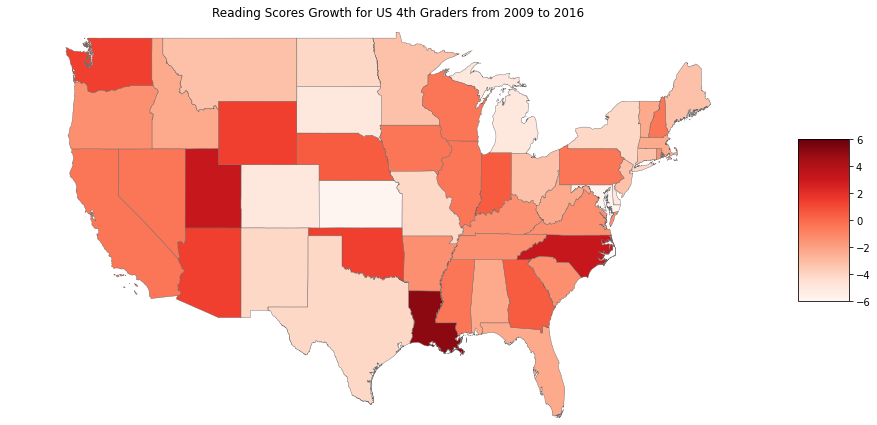

```python
fig, ax = plt.subplots(1, figsize=(14, 14))
plt.xticks(rotation=90)
map_data.plot(column = "READING", cmap = "Reds", linewidth = 0.4, ax = ax, edgecolor = ".4")
ax.set_title('Reading Scores Growth for US 4th Graders from 2009 to 2016')
color_grade = plt.cm.ScalarMappable(cmap="Reds", norm=plt.Normalize(vmin= -6, vmax=6))
color_axis = fig.add_axes([ax.get_position().x1 + 0.01,ax.get_position().y0,0.05,ax.get_position().height])
cbar = fig.colorbar(color_grade, cax = color_axis)
ax.set_xlim(-130, -60)
ax.set_ylim(25, 50)
ax.axis("off")
```

## Observations:

The heatmap above shows the change in reading literacy among 4th graders in the United States from 2009 to 2015. The heatmap shows that not all states have experienced the same growth in reading literacy, indicating that there may be educational inequality among states. Some states, such as Louisiana and North Carolina, have seen positive growth in reading literacy, while others, such as Kansas and Maryland, have seen a decline. This suggests that reading literacy growth may be dependent on the state and that educational inequality may exist.

```
(-130.0, -60.0, 25.0, 50.0)
```

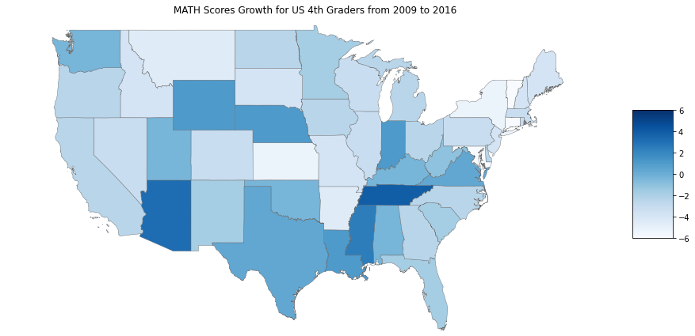

```python
fig, ax = plt.subplots(1, figsize=(14, 14))
plt.xticks(rotation=90)
map_data.plot(column = "MATH", cmap = "Blues", linewidth = 0.4, ax = ax, edgecolor = ".4")
ax.set_title('MATH Scores Growth for US 4th Graders from 2009 to 2016')
color_grade = plt.cm.ScalarMappable(cmap="Blues", norm=plt.Normalize(vmin= -6, vmax=6))
color_axis = fig.add_axes([ax.get_position().x1 + 0.01,ax.get_position().y0,0.05,ax.get_position().height])
cbar = fig.colorbar(color_grade, cax = color_axis)
ax.set_xlim(-130, -60)
ax.set_ylim(25, 50)
ax.axis("off")
```

# Part 4: Hypothesis Testing

```python
#finding the average read writing scores for each
avg_score = school[['STATE', 'YEAR', 'G04_A_A_READING', 'G04_A_A_MATHEMATICS']]

avg_score
```

|  | STATE | YEAR | G04_A_A_READING | G04_A_A_MATHEMATICS |
| --- | --- | --- | --- | --- |
| 867 | ALABAMA | 2009 | 216.0 | 228.0 |
| 868 | ALASKA | 2009 | 211.0 | 237.0 |
| 869 | ARIZONA | 2009 | 210.0 | 230.0 |
| 870 | ARKANSAS | 2009 | 216.0 | 238.0 |
| 871 | CALIFORNIA | 2009 | 210.0 | 232.0 |
| ... | ... | ... | ... | ... |
| 1710 | VIRGINIA | 2019 | 224.0 | 247.0 |
| 1711 | WASHINGTON | 2019 | 220.0 | 240.0 |
| 1712 | WEST_VIRGINIA | 2019 | 213.0 | 231.0 |
| 1713 | WISCONSIN | 2019 | 220.0 | 242.0 |
| 1714 | WYOMING | 2019 | 227.0 | 246.0 |

522 rows × 4 columns

Our formula for getting the growth of reading and math score, we subtracted the 2009 average score from each data point (2010-2019)  
This is our score change, which we will use for both math (MATH_CHANGE) and reading (READING_CHANGE)

### MATH_CHANGE

```python
#MATH CHANGE

#set MATH_CHANGE = NaN
avg_score['MATH_CHANGE'] = np.NaN

#function to find and return average math for 2009
def find_math_scores_2009(row):
    state_row = row['STATE']
    new = avg_score.loc[avg_score['STATE'] == state_row]
    new = new.loc[new['YEAR'] == 2009]
    return new['G04_A_A_MATHEMATICS']

# Subtract the 2009 average score from each data point (2010-2019)
for i, row in avg_score.iterrows():
    avg_score.at[i, 'MATH_CHANGE'] = row['G04_A_A_MATHEMATICS'] - find_math_scores_2009(row)

avg_score
```

|  | STATE | YEAR | G04_A_A_READING | G04_A_A_MATHEMATICS | MATH_CHANGE |
| --- | --- | --- | --- | --- | --- |
| 867 | ALABAMA | 2009 | 216.0 | 228.0 | 0.0 |
| 868 | ALASKA | 2009 | 211.0 | 237.0 | 0.0 |
| 869 | ARIZONA | 2009 | 210.0 | 230.0 | 0.0 |
| 870 | ARKANSAS | 2009 | 216.0 | 238.0 | 0.0 |
| 871 | CALIFORNIA | 2009 | 210.0 | 232.0 | 0.0 |
| ... | ... | ... | ... | ... | ... |
| 1710 | VIRGINIA | 2019 | 224.0 | 247.0 | 4.0 |
| 1711 | WASHINGTON | 2019 | 220.0 | 240.0 | -2.0 |
| 1712 | WEST_VIRGINIA | 2019 | 213.0 | 231.0 | -2.0 |
| 1713 | WISCONSIN | 2019 | 220.0 | 242.0 | -2.0 |
| 1714 | WYOMING | 2019 | 227.0 | 246.0 | 4.0 |

522 rows × 5 columns

### READING_CHANGE

```python
#MATH CHANGE

#set READING_CHANGE = NaN
avg_score['READING_CHANGE'] = np.NaN

#function to find and return average reading for 2009
def find_reading_scores_2009(row):
    state_row = row['STATE']
    new = avg_score.loc[avg_score['STATE'] == state_row]
    new = new.loc[new['YEAR'] == 2009]
    return new['G04_A_A_READING']

# Subtract the 2009 average score from each data point (2010-2019)
for i, row in avg_score.iterrows():
    avg_score.at[i, 'READING_CHANGE'] = row['G04_A_A_READING'] - find_reading_scores_2009(row)

avg_score.head()
```

|  | STATE | YEAR | G04_A_A_READING | G04_A_A_MATHEMATICS | MATH_CHANGE | READING_CHANGE |
| --- | --- | --- | --- | --- | --- | --- |
| 867 | ALABAMA | 2009 | 216.0 | 228.0 | 0.0 | 0.0 |
| 868 | ALASKA | 2009 | 211.0 | 237.0 | 0.0 | 0.0 |
| 869 | ARIZONA | 2009 | 210.0 | 230.0 | 0.0 | 0.0 |
| 870 | ARKANSAS | 2009 | 216.0 | 238.0 | 0.0 | 0.0 |
| 871 | CALIFORNIA | 2009 | 210.0 | 232.0 | 0.0 | 0.0 |

We can use the pandas method get_dummies to create a dataframe where each state is represented by a binary value (1 or 0) indicating whether the data value is in that state or not. We can then drop the Alabama column because if all other state columns are 0, we can assume the data value must be in Alabama. This is possible because each state is treated as a unique, independent variable.

```python
# get dummies
avg_score = pd.get_dummies(avg_score, columns=['STATE'])
```

We can then drop the Alabama column because if all other state columns are 0, we can assume the data value must be in Alabama. This is possible because each state is treated as a unique, independent variable.

```python
# drop alabama and reading and mathematics averages since we no longer need them
state_avg = avg_score.drop(columns=['STATE_ALABAMA', 'G04_A_A_READING', 'G04_A_A_MATHEMATICS'])
avg_score.head()
```

|  | YEAR | G04_A_A_READING | G04_A_A_MATHEMATICS | MATH_CHANGE | READING_CHANGE | STATE_ALABAMA | STATE_ALASKA | STATE_ARIZONA | STATE_ARKANSAS | STATE_CALIFORNIA | ... | STATE_SOUTH_DAKOTA | STATE_TENNESSEE | STATE_TEXAS | STATE_UTAH | STATE_VERMONT | STATE_VIRGINIA | STATE_WASHINGTON | STATE_WEST_VIRGINIA | STATE_WISCONSIN | STATE_WYOMING |
| --- | --- | --- | --- | --- | --- | --- | --- | --- | --- | --- | --- | --- | --- | --- | --- | --- | --- | --- | --- | --- | --- |
| 867 | 2009 | 216.0 | 228.0 | 0.0 | 0.0 | 1 | 0 | 0 | 0 | 0 | ... | 0 | 0 | 0 | 0 | 0 | 0 | 0 | 0 | 0 | 0 |
| 868 | 2009 | 211.0 | 237.0 | 0.0 | 0.0 | 0 | 1 | 0 | 0 | 0 | ... | 0 | 0 | 0 | 0 | 0 | 0 | 0 | 0 | 0 | 0 |
| 869 | 2009 | 210.0 | 230.0 | 0.0 | 0.0 | 0 | 0 | 1 | 0 | 0 | ... | 0 | 0 | 0 | 0 | 0 | 0 | 0 | 0 | 0 | 0 |
| 870 | 2009 | 216.0 | 238.0 | 0.0 | 0.0 | 0 | 0 | 0 | 1 | 0 | ... | 0 | 0 | 0 | 0 | 0 | 0 | 0 | 0 | 0 | 0 |
| 871 | 2009 | 210.0 | 232.0 | 0.0 | 0.0 | 0 | 0 | 0 | 0 | 1 | ... | 0 | 0 | 0 | 0 | 0 | 0 | 0 | 0 | 0 | 0 |

5 rows × 58 columns

In order to evaluate the accuracy of our predictor, we need to split our dataset into a training set and a test set. The training set will be used to train the predictor, and the test set will be used to evaluate its performance. In this case, we want to predict the values for the years 2017, 2018, and 2019, so we will use those rows as our test data and the remaining rows as our train data. We will first start the training data by dropping the NaN rows

```python
# drop the NaN rows
trainer = state_avg[state_avg['YEAR'] < 2017].dropna()
predictor = state_avg[state_avg['YEAR'] >= 2017].dropna()
```

```python
from sklearn.linear_model import LinearRegression

X_reading = []
y_reading = []
X_math = []
y_math = []

# iterate through each row and add the year and state to the X variables and the growths to the y variables
for i, row in trainer.iterrows():
    add = row[3:].tolist()
    add.insert(0, row['YEAR'])
    X_reading.append(add)
    y_reading.append(row['READING_CHANGE'])
    X_math.append(add)
    y_math.append(row['MATH_CHANGE'])

trainer
```

|  | YEAR | MATH_CHANGE | READING_CHANGE | STATE_ALASKA | STATE_ARIZONA | STATE_ARKANSAS | STATE_CALIFORNIA | STATE_COLORADO | STATE_CONNECTICUT | STATE_DELAWARE | ... | STATE_SOUTH_DAKOTA | STATE_TENNESSEE | STATE_TEXAS | STATE_UTAH | STATE_VERMONT | STATE_VIRGINIA | STATE_WASHINGTON | STATE_WEST_VIRGINIA | STATE_WISCONSIN | STATE_WYOMING |
| --- | --- | --- | --- | --- | --- | --- | --- | --- | --- | --- | --- | --- | --- | --- | --- | --- | --- | --- | --- | --- | --- |
| 867 | 2009 | 0.0 | 0.0 | 0 | 0 | 0 | 0 | 0 | 0 | 0 | ... | 0 | 0 | 0 | 0 | 0 | 0 | 0 | 0 | 0 | 0 |
| 868 | 2009 | 0.0 | 0.0 | 1 | 0 | 0 | 0 | 0 | 0 | 0 | ... | 0 | 0 | 0 | 0 | 0 | 0 | 0 | 0 | 0 | 0 |
| 869 | 2009 | 0.0 | 0.0 | 0 | 1 | 0 | 0 | 0 | 0 | 0 | ... | 0 | 0 | 0 | 0 | 0 | 0 | 0 | 0 | 0 | 0 |
| 870 | 2009 | 0.0 | 0.0 | 0 | 0 | 1 | 0 | 0 | 0 | 0 | ... | 0 | 0 | 0 | 0 | 0 | 0 | 0 | 0 | 0 | 0 |
| 871 | 2009 | 0.0 | 0.0 | 0 | 0 | 0 | 1 | 0 | 0 | 0 | ... | 0 | 0 | 0 | 0 | 0 | 0 | 0 | 0 | 0 | 0 |
| ... | ... | ... | ... | ... | ... | ... | ... | ... | ... | ... | ... | ... | ... | ... | ... | ... | ... | ... | ... | ... | ... |
| 1655 | 2011 | 1.0 | 0.0 | 0 | 0 | 0 | 0 | 0 | 0 | 0 | ... | 0 | 0 | 0 | 0 | 0 | 0 | 0 | 0 | 0 | 0 |
| 1656 | 2013 | 5.0 | 4.0 | 0 | 0 | 0 | 0 | 0 | 0 | 0 | ... | 0 | 0 | 0 | 0 | 0 | 0 | 0 | 0 | 0 | 0 |
| 1657 | 2013 | 2.0 | 1.0 | 0 | 0 | 0 | 0 | 0 | 0 | 0 | ... | 0 | 0 | 0 | 0 | 0 | 0 | 0 | 0 | 0 | 0 |
| 1658 | 2015 | 8.0 | 6.0 | 0 | 0 | 0 | 0 | 0 | 0 | 0 | ... | 0 | 0 | 0 | 0 | 0 | 0 | 0 | 0 | 0 | 0 |
| 1659 | 2015 | 0.0 | 2.0 | 0 | 0 | 0 | 0 | 0 | 0 | 0 | ... | 0 | 0 | 0 | 0 | 0 | 0 | 0 | 0 | 0 | 0 |

212 rows × 55 columns

To create a linear regression model that can make predictions on our data, we need to first separate our data into independent and dependent variables. The independent variables are the factors that we will use to make predictions, while the dependent variables are the values that we want to predict.

```python
from sklearn.linear_model import LinearRegression

X_tester_reading = []
X_tester_math = []

reading_regression = LinearRegression().fit(X_reading, y_reading)
math_regression = LinearRegression().fit(X_math, y_math)

# accumulate X values for reading and math
for i, row in predictor.iterrows():
    add = row[3:].tolist()
    add.insert(0, row['YEAR'])
    X_tester_reading.append(add)
    X_tester_math.append(add)

# predict based of X values
predictor['PREDICT_MATH'] = reading_regression.predict(X_tester_reading)
predictor['PREDICT_READING'] = reading_regression.predict(X_tester_reading)


predictor
```

|  | YEAR | MATH_CHANGE | READING_CHANGE | STATE_ALASKA | STATE_ARIZONA | STATE_ARKANSAS | STATE_CALIFORNIA | STATE_COLORADO | STATE_CONNECTICUT | STATE_DELAWARE | ... | STATE_TEXAS | STATE_UTAH | STATE_VERMONT | STATE_VIRGINIA | STATE_WASHINGTON | STATE_WEST_VIRGINIA | STATE_WISCONSIN | STATE_WYOMING | PREDICT_MATH | PREDICT_READING |
| --- | --- | --- | --- | --- | --- | --- | --- | --- | --- | --- | --- | --- | --- | --- | --- | --- | --- | --- | --- | --- | --- |
| 1281 | 2017 | 4.0 | 0.0 | 0 | 0 | 0 | 0 | 0 | 0 | 0 | ... | 0 | 0 | 0 | 0 | 0 | 0 | 0 | 0 | 3.712264 | 3.712264 |
| 1288 | 2017 | -7.0 | -4.0 | 1 | 0 | 0 | 0 | 0 | 0 | 0 | ... | 0 | 0 | 0 | 0 | 0 | 0 | 0 | 0 | 0.962264 | 0.962264 |
| 1295 | 2017 | 4.0 | 5.0 | 0 | 1 | 0 | 0 | 0 | 0 | 0 | ... | 0 | 0 | 0 | 0 | 0 | 0 | 0 | 0 | 4.212264 | 4.212264 |
| 1302 | 2017 | -4.0 | 0.0 | 0 | 0 | 1 | 0 | 0 | 0 | 0 | ... | 0 | 0 | 0 | 0 | 0 | 0 | 0 | 0 | 3.212264 | 3.212264 |
| 1309 | 2017 | 0.0 | 5.0 | 0 | 0 | 0 | 1 | 0 | 0 | 0 | ... | 0 | 0 | 0 | 0 | 0 | 0 | 0 | 0 | 3.462264 | 3.462264 |
| ... | ... | ... | ... | ... | ... | ... | ... | ... | ... | ... | ... | ... | ... | ... | ... | ... | ... | ... | ... | ... | ... |
| 1710 | 2019 | 4.0 | -3.0 | 0 | 0 | 0 | 0 | 0 | 0 | 0 | ... | 0 | 0 | 0 | 1 | 0 | 0 | 0 | 0 | 3.147170 | 3.147170 |
| 1711 | 2019 | -2.0 | -1.0 | 0 | 0 | 0 | 0 | 0 | 0 | 0 | ... | 0 | 0 | 0 | 0 | 1 | 0 | 0 | 0 | 4.647170 | 4.647170 |
| 1712 | 2019 | -2.0 | -2.0 | 0 | 0 | 0 | 0 | 0 | 0 | 0 | ... | 0 | 0 | 0 | 0 | 0 | 1 | 0 | 0 | 2.397170 | 2.397170 |
| 1713 | 2019 | -2.0 | 0.0 | 0 | 0 | 0 | 0 | 0 | 0 | 0 | ... | 0 | 0 | 0 | 0 | 0 | 0 | 1 | 0 | 3.647170 | 3.647170 |
| 1714 | 2019 | 4.0 | 4.0 | 0 | 0 | 0 | 0 | 0 | 0 | 0 | ... | 0 | 0 | 0 | 0 | 0 | 0 | 0 | 1 | 4.647170 | 4.647170 |

106 rows × 57 columns

To determine whether being in a particular state has an effect on the growth of reading and math test scores, we can use the statsmodel library to calculate the p-value of each coefficient that we pass into the model. The p-value is a measure of statistical significance that indicates the probability that the observed relationship between a given independent variable and the dependent variable is due to chance. If the p-value is below a certain threshold (usually 0.05), we can conclude that the relationship is statistically significant and that the independent variable has a significant effect on the dependent variable.

```python
import statsmodels.api as sm
```

```python
# create statsmodel for math data
predict_math = sm.OLS(trainer['MATH_CHANGE'].tolist(), sm.add_constant(X_math)).fit()
predict_math.summary()
```

OLS Regression Results

| Dep. Variable: | y | R-squared: | 0.511 |
| --- | --- | --- | --- |
| Model: | OLS | Adj. R-squared: | 0.346 |
| Method: | Least Squares | F-statistic: | 3.110 |
| Date: | Thu, 08 Dec 2022 | Prob (F-statistic): | 2.35e-08 |
| Time: | 02:36:48 | Log-Likelihood: | -420.79 |
| No. Observations: | 212 | AIC: | 949.6 |
| Df Residuals: | 158 | BIC: | 1131. |
| Df Model: | 53 |  |  |
| Covariance Type: | nonrobust |  |  |

|  | coef | std err | t | P>\|t\| | [0.025 | 0.975] |
| --- | --- | --- | --- | --- | --- | --- |
| const | -407.2425 | 126.068 | -3.230 | 0.002 | -656.238 | -158.247 |
| x1 | 0.2038 | 0.063 | 3.252 | 0.001 | 0.080 | 0.328 |
| x2 | -3.5000 | 1.442 | -2.426 | 0.016 | -6.349 | -0.651 |
| x3 | 3.0000 | 1.442 | 2.080 | 0.039 | 0.151 | 5.849 |
| x4 | -3.0000 | 1.442 | -2.080 | 0.039 | -5.849 | -0.151 |
| x5 | -1.7500 | 1.442 | -1.213 | 0.227 | -4.599 | 1.099 |
| x6 | -1.7500 | 1.442 | -1.213 | 0.227 | -4.599 | 1.099 |
| x7 | -5.2500 | 1.442 | -3.640 | 0.000 | -8.099 | -2.401 |
| x8 | -1.5000 | 1.442 | -1.040 | 0.300 | -4.349 | 1.349 |
| x9 | 3.5000 | 1.442 | 2.426 | 0.016 | 0.651 | 6.349 |
| x10 | 0.7500 | 1.442 | 0.520 | 0.604 | -2.099 | 3.599 |
| x11 | -3.0000 | 1.442 | -2.080 | 0.039 | -5.849 | -0.151 |
| x12 | -1.2500 | 1.442 | -0.867 | 0.387 | -4.099 | 1.599 |
| x13 | 0.2500 | 1.442 | 0.173 | 0.863 | -2.599 | 3.099 |
| x14 | -3.5000 | 1.442 | -2.426 | 0.016 | -6.349 | -0.651 |
| x15 | -2.5000 | 1.442 | -1.733 | 0.085 | -5.349 | 0.349 |
| x16 | 0.2500 | 1.442 | 0.173 | 0.863 | -2.599 | 3.099 |
| x17 | -2.0000 | 1.442 | -1.387 | 0.168 | -4.849 | 0.849 |
| x18 | -3.2500 | 1.442 | -2.253 | 0.026 | -6.099 | -0.401 |
| x19 | -1.0000 | 1.442 | -0.693 | 0.489 | -3.849 | 1.849 |
| x20 | -0.5000 | 1.442 | -0.347 | 0.729 | -3.349 | 2.349 |
| x21 | -2.7500 | 1.442 | -1.906 | 0.058 | -5.599 | 0.099 |
| x22 | -3.0000 | 1.442 | -2.080 | 0.039 | -5.849 | -0.151 |
| x23 | -2.5000 | 1.442 | -1.733 | 0.085 | -5.349 | 0.349 |
| x24 | -2.5000 | 1.442 | -1.733 | 0.085 | -5.349 | 0.349 |
| x25 | -1.5000 | 1.442 | -1.040 | 0.300 | -4.349 | 1.349 |
| x26 | 0.7500 | 1.442 | 0.520 | 0.604 | -2.099 | 3.599 |
| x27 | -3.7500 | 1.442 | -2.600 | 0.010 | -6.599 | -0.901 |
| x28 | -3.5000 | 1.442 | -2.426 | 0.016 | -6.349 | -0.651 |
| x29 | -2.0000 | 1.442 | -1.387 | 0.168 | -4.849 | 0.849 |
| x30 | -0.2500 | 1.442 | -0.173 | 0.863 | -3.099 | 2.599 |
| x31 | -2.2500 | 1.442 | -1.560 | 0.121 | -5.099 | 0.599 |
| x32 | -2.5000 | 1.442 | -1.733 | 0.085 | -5.349 | 0.349 |
| x33 | -3.0000 | 1.442 | -2.080 | 0.039 | -5.849 | -0.151 |
| x34 | -1.0000 | 1.442 | -0.693 | 0.489 | -3.849 | 1.849 |
| x35 | -4.7500 | 1.442 | -3.293 | 0.001 | -7.599 | -1.901 |
| x36 | -2.2500 | 1.442 | -1.560 | 0.121 | -5.099 | 0.599 |
| x37 | -2.5000 | 1.442 | -1.733 | 0.085 | -5.349 | 0.349 |
| x38 | -2.2500 | 1.442 | -1.560 | 0.121 | -5.099 | 0.599 |
| x39 | -1.5000 | 1.442 | -1.040 | 0.300 | -4.349 | 1.349 |
| x40 | -2.5000 | 1.442 | -1.733 | 0.085 | -5.349 | 0.349 |
| x41 | -2.5000 | 1.442 | -1.733 | 0.085 | -5.349 | 0.349 |
| x42 | -1.7500 | 1.442 | -1.213 | 0.227 | -4.599 | 1.099 |
| x43 | -2.0000 | 1.442 | -1.387 | 0.168 | -4.849 | 0.849 |
| x44 | -3.7500 | 1.442 | -2.600 | 0.010 | -6.599 | -0.901 |
| x45 | 1.7500 | 1.442 | 1.213 | 0.227 | -1.099 | 4.599 |
| x46 | -1.0000 | 1.442 | -0.693 | 0.489 | -3.849 | 1.849 |
| x47 | -0.5000 | 1.442 | -0.347 | 0.729 | -3.349 | 2.349 |
| x48 | -4.2500 | 1.442 | -2.946 | 0.004 | -7.099 | -1.401 |
| x49 | -0.5000 | 1.442 | -0.347 | 0.729 | -3.349 | 2.349 |
| x50 | -0.7500 | 1.442 | -0.520 | 0.604 | -3.599 | 2.099 |
| x51 | -0.7500 | 1.442 | -0.520 | 0.604 | -3.599 | 2.099 |
| x52 | -2.5000 | 1.442 | -1.733 | 0.085 | -5.349 | 0.349 |
| x53 | 0.2500 | 1.442 | 0.173 | 0.863 | -2.599 | 3.099 |

| Omnibus: | 6.335 | Durbin-Watson: | 1.739 |
| --- | --- | --- | --- |
| Prob(Omnibus): | 0.042 | Jarque-Bera (JB): | 6.673 |
| Skew: | -0.294 | Prob(JB): | 0.0356 |
| Kurtosis: | 3.639 | Cond. No. | 1.81e+06 |

Notes:  
[1] Standard Errors assume that the covariance matrix of the errors is correctly specified.  
[2] The condition number is large, 1.81e+06. This might indicate that there are  
strong multicollinearity or other numerical problems.

```python
# create statsmodel for reading data
predict_reading = sm.OLS(trainer['READING_CHANGE'].tolist(), sm.add_constant(X_reading)).fit()
predict_reading.summary()
```

OLS Regression Results

| Dep. Variable: | y | R-squared: | 0.511 |
| --- | --- | --- | --- |
| Model: | OLS | Adj. R-squared: | 0.347 |
| Method: | Least Squares | F-statistic: | 3.113 |
| Date: | Thu, 08 Dec 2022 | Prob (F-statistic): | 2.28e-08 |
| Time: | 02:36:48 | Log-Likelihood: | -394.27 |
| No. Observations: | 212 | AIC: | 896.5 |
| Df Residuals: | 158 | BIC: | 1078. |
| Df Model: | 53 |  |  |
| Covariance Type: | nonrobust |  |  |

|  | coef | std err | t | P>\|t\| | [0.025 | 0.975] |
| --- | --- | --- | --- | --- | --- | --- |
| const | -687.0151 | 111.242 | -6.176 | 0.000 | -906.729 | -467.301 |
| x1 | 0.3425 | 0.055 | 6.194 | 0.000 | 0.233 | 0.452 |
| x2 | -2.7500 | 1.273 | -2.161 | 0.032 | -5.264 | -0.236 |
| x3 | 0.5000 | 1.273 | 0.393 | 0.695 | -2.014 | 3.014 |
| x4 | -0.5000 | 1.273 | -0.393 | 0.695 | -3.014 | 2.014 |
| x5 | -0.2500 | 1.273 | -0.196 | 0.845 | -2.764 | 2.264 |
| x6 | -3.0000 | 1.273 | -2.357 | 0.020 | -5.514 | -0.486 |
| x7 | -2.2500 | 1.273 | -1.768 | 0.079 | -4.764 | 0.264 |
| x8 | -2.7500 | 1.273 | -2.161 | 0.032 | -5.264 | -0.236 |
| x9 | 1.2500 | 1.273 | 0.982 | 0.328 | -1.264 | 3.764 |
| x10 | 0.7500 | 1.273 | 0.589 | 0.557 | -1.764 | 3.264 |
| x11 | -1.7500 | 1.273 | -1.375 | 0.171 | -4.264 | 0.764 |
| x12 | 0.7500 | 1.273 | 0.589 | 0.557 | -1.764 | 3.264 |
| x13 | 0.7500 | 1.273 | 0.589 | 0.557 | -1.764 | 3.264 |
| x14 | -2.2500 | 1.273 | -1.768 | 0.079 | -4.764 | 0.264 |
| x15 | -1.2500 | 1.273 | -0.982 | 0.328 | -3.764 | 1.264 |
| x16 | -1.0000 | 1.273 | -0.786 | 0.433 | -3.514 | 1.514 |
| x17 | -0.5000 | 1.273 | -0.393 | 0.695 | -3.014 | 2.014 |
| x18 | -3.0000 | 1.273 | -2.357 | 0.020 | -5.514 | -0.486 |
| x19 | -2.2500 | 1.273 | -1.768 | 0.079 | -4.764 | 0.264 |
| x20 | 1.7500 | 1.273 | 1.375 | 0.171 | -0.764 | 4.264 |
| x21 | -2.2500 | 1.273 | -1.768 | 0.079 | -4.764 | 0.264 |
| x22 | 1.344e-12 | 1.273 | 1.06e-12 | 1.000 | -2.514 | 2.514 |
| x23 | -1.5000 | 1.273 | -1.178 | 0.240 | -4.014 | 1.014 |
| x24 | -2.5000 | 1.273 | -1.964 | 0.051 | -5.014 | 0.014 |
| x25 | -1.2500 | 1.273 | -0.982 | 0.328 | -3.764 | 1.264 |
| x26 | -2.2500 | 1.273 | -1.768 | 0.079 | -4.764 | 0.264 |
| x27 | -3.7500 | 1.273 | -2.946 | 0.004 | -6.264 | -1.236 |
| x28 | -2.5000 | 1.273 | -1.964 | 0.051 | -5.014 | 0.014 |
| x29 | -1.2500 | 1.273 | -0.982 | 0.328 | -3.764 | 1.264 |
| x30 | -1.0000 | 1.273 | -0.786 | 0.433 | -3.514 | 1.514 |
| x31 | 1.347e-12 | 1.273 | 1.06e-12 | 1.000 | -2.514 | 2.514 |
| x32 | -0.2500 | 1.273 | -0.196 | 0.845 | -2.764 | 2.264 |
| x33 | -1.5000 | 1.273 | -1.178 | 0.240 | -4.014 | 1.014 |
| x34 | -2.7500 | 1.273 | -2.161 | 0.032 | -5.264 | -0.236 |
| x35 | -2.7500 | 1.273 | -2.161 | 0.032 | -5.264 | -0.236 |
| x36 | 1.0000 | 1.273 | 0.786 | 0.433 | -1.514 | 3.514 |
| x37 | -2.7500 | 1.273 | -2.161 | 0.032 | -5.264 | -0.236 |
| x38 | -2.5000 | 1.273 | -1.964 | 0.051 | -5.014 | 0.014 |
| x39 | -1.2500 | 1.273 | -0.982 | 0.328 | -3.764 | 1.264 |
| x40 | -1.7500 | 1.273 | -1.375 | 0.171 | -4.264 | 0.764 |
| x41 | 1.345e-12 | 1.273 | 1.06e-12 | 1.000 | -2.514 | 2.514 |
| x42 | -1.7500 | 1.273 | -1.375 | 0.171 | -4.264 | 0.764 |
| x43 | -2.2500 | 1.273 | -1.768 | 0.079 | -4.764 | 0.264 |
| x44 | -4.0000 | 1.273 | -3.143 | 0.002 | -6.514 | -1.486 |
| x45 | -1.2500 | 1.273 | -0.982 | 0.328 | -3.764 | 1.264 |
| x46 | -3.0000 | 1.273 | -2.357 | 0.020 | -5.514 | -0.486 |
| x47 | 1.0000 | 1.273 | 0.786 | 0.433 | -1.514 | 3.514 |
| x48 | -2.5000 | 1.273 | -1.964 | 0.051 | -5.014 | 0.014 |
| x49 | -1.2500 | 1.273 | -0.982 | 0.328 | -3.764 | 1.264 |
| x50 | 0.2500 | 1.273 | 0.196 | 0.845 | -2.264 | 2.764 |
| x51 | -2.0000 | 1.273 | -1.571 | 0.118 | -4.514 | 0.514 |
| x52 | -0.7500 | 1.273 | -0.589 | 0.557 | -3.264 | 1.764 |
| x53 | 0.2500 | 1.273 | 0.196 | 0.845 | -2.264 | 2.764 |

| Omnibus: | 6.181 | Durbin-Watson: | 2.013 |
| --- | --- | --- | --- |
| Prob(Omnibus): | 0.045 | Jarque-Bera (JB): | 9.162 |
| Skew: | 0.103 | Prob(JB): | 0.0102 |
| Kurtosis: | 3.997 | Cond. No. | 1.81e+06 |

Notes:  
[1] Standard Errors assume that the covariance matrix of the errors is correctly specified.  
[2] The condition number is large, 1.81e+06. This might indicate that there are  
strong multicollinearity or other numerical problems.

```python
# accumulate constant names
const_names = trainer.columns[3:].tolist()
const_names.insert(0, 'YEAR')

math_significant = []
```

Iterate through p values and if less than 0.05 add to math_significant

```python
for i in range(len(predict_math.pvalues) - 1):
    if predict_math.pvalues[i + 1] < 0.05:
        math_significant.append(const_names[i])

print("Math Constraints Tested: : " + str(math_significant))
```

```
Math Constraints Tested: : ['YEAR', 'STATE_ALASKA', 'STATE_ARIZONA', 'STATE_ARKANSAS', 'STATE_CONNECTICUT', 'STATE_DISTRICT_OF_COLUMBIA', 'STATE_FLORIDA', 'STATE_IDAHO', 'STATE_KANSAS', 'STATE_MARYLAND', 'STATE_MISSOURI', 'STATE_MONTANA', 'STATE_NEW_JERSEY', 'STATE_NEW_YORK', 'STATE_SOUTH_DAKOTA', '…
```

Iterate through p values and if less than 0.05 add to reading_significant

```python
reading_significant = []


for i in range(len(predict_reading.pvalues) - 1):
    if predict_reading.pvalues[i + 1] < 0.05:
        reading_significant.append(const_names[i])

print("Reading Constraints Tested: " + str(reading_significant))
print()
```

```
Reading Constraints Tested: ['YEAR', 'STATE_ALASKA', 'STATE_COLORADO', 'STATE_DELAWARE', 'STATE_KANSAS', 'STATE_MISSOURI', 'STATE_NEW_MEXICO', 'STATE_NEW_YORK', 'STATE_NORTH_DAKOTA', 'STATE_SOUTH_DAKOTA', 'STATE_TEXAS']
```

Checks MATH p-values and coffeficients from the regression model and prints out that specific states name

```python
print("Predicted Negative Growth in Math:")

for i in range(len(math_regression.coef_)):
    if(i > 1):
        if math_regression.coef_[i] < 0 and predict_math.pvalues[i + 1] < 0.05:
            print(const_names[i])
```

```
Predicted Negative Growth in Math:
STATE_ARKANSAS
STATE_CONNECTICUT
STATE_FLORIDA
STATE_IDAHO
STATE_KANSAS
STATE_MARYLAND
STATE_MISSOURI
STATE_MONTANA
STATE_NEW_JERSEY
STATE_NEW_YORK
STATE_SOUTH_DAKOTA
STATE_VERMONT
```

Checks READING p-values and coffeficients from the regression model and prints out that specific states name

```python
print("Predicted Negative Growth in Reading:")

for i in range(len(reading_regression.coef_)):
    if(i > 1):
        if reading_regression.coef_[i] < 0 and predict_reading.pvalues[i + 1] < 0.05:
            print(const_names[i])
```

```
Predicted Negative Growth in Reading:
STATE_COLORADO
STATE_DELAWARE
STATE_KANSAS
STATE_MISSOURI
STATE_NEW_MEXICO
STATE_NEW_YORK
STATE_NORTH_DAKOTA
STATE_SOUTH_DAKOTA
STATE_TEXAS
```

## Part 5 - Conclusion

We hope that these models and our exploratory data analysis can be used by policymakers to identify which states and which demographics within states need more support in developing math and reading curriculum and hiring educators. State within state play a role in math and reading literacy, and changes need to be made to provide equitable education to all.